# U.S. Unique Dialects in R

Jessica Blanton

2024-10-23

### **Our Question**: What states have the most unique words as classified by the Dictionary of American Regional English?

[Dataset obtained from www.kaggle.com](https://www.kaggle.com/datasets/rtatman/dictionary-of-american-regional-english-dareds)

- *Rahimi, Afshin, Cohn, Trevor and Baldwin, Timothy. “A Neural Model for User Geolocation and Lexical Dialectology.” ACL 2017 (2017): 209.*
- *Cassidy, F. G. (1985). Dictionary of American Regional English. Belknap Press of Harvard University Press.*

Set your working directory to the place where you saved your downloaded files

```r
setwd("[Enter your path here]")
```

Install required packages

```r
# # Install and load useful magrittr package (Ceci n'est pas une pipe!)
install.packages("jsonlite")
install.packages("magrittr")
install.packages("tidyverse")
install.packages("maps")
install.packages("mapproj")
install.packages("devtools")
devtools::install_github("wmurphyrd/fiftystater", force = T)
```

Load packages for this R session

```r
library(jsonlite)
library(magrittr)
library(tidyverse) #this includes "dplyr" and "ggplot2"
library(maps)
library(mapproj)
library(fiftystater)
```

```r
# Import data
daredes <- fromJSON(txt = "geodare.json", simplifyVector = T)
# Expect this warning message:
#   JSON string contains (illegal) UTF8 byte-order-mark!

# Tidy up column names
names(daredes) <- make.names(names(daredes))

# Make state index case-matchable
state.lc <- state.name%>%tolower()

# Select only states from full DARE list (includes regions)
daredes.st <- daredes[(daredes$dialect)%in%state.lc,]
```

Look at words in some states of interest

```r
daredes.st[daredes.st$dialect=="massachusetts",] %>% head
daredes.st[daredes.st$dialect=="ohio",] %>% head
daredes.st[daredes.st$dialect=="texas",] %>% head
daredes.st[daredes.st$dialect=="louisiana",] %>% head
```

Summarize the count of state-specific words, in decreasing order

```r
daredes.count <- daredes.st%>%
  group_by(dialect)%>%
  summarize(count=n())%>%
  .[ order(.$count,decreasing = T),]
```

Look at states with largest count of unique words

```r
# Print contents to console
daredes.count
```

```
## # A tibble: 50 × 2
##    dialect        count
##    <chr>          <int>
##  1 hawaii           205
##  2 texas            124
##  3 louisiana        102
##  4 pennsylvania      97
##  5 california        89
##  6 maine             66
##  7 alaska            56
##  8 new york          55
##  9 wisconsin         53
## 10 south carolina    41
## # ℹ 40 more rows
```

```r
# Or open as a tab within RStudio
View(daredes.count)
```

### Plot using `ggplot2` & `maps` packages

Get plotting location data from `maps` package library

```r
states <- map_data("state")

# Explore this "states" data frame
head(states,50)
```

Merge and sort

```r
dialects.geo <- merge(states, daredes.count, sort = FALSE,
                      by.x = "region", by.y ="dialect", all.x = T)

dialects.geo <- dialects.geo[order(dialects.geo$count,decreasing = T), ]

# Check that no entries are missing between the merged tables
setdiff(states$region,dialects.geo$region)
setdiff(dialects.geo$region,states$region)
```

Plot the map with ggplot

Components of the visualization are mapped as layers

- **Coordinates**
- Statistics
- Facets
- **Geometry**
- **Aesthetics**
- **Data**

Let’s map this layer by layer to see how modifications to the intial figure are made

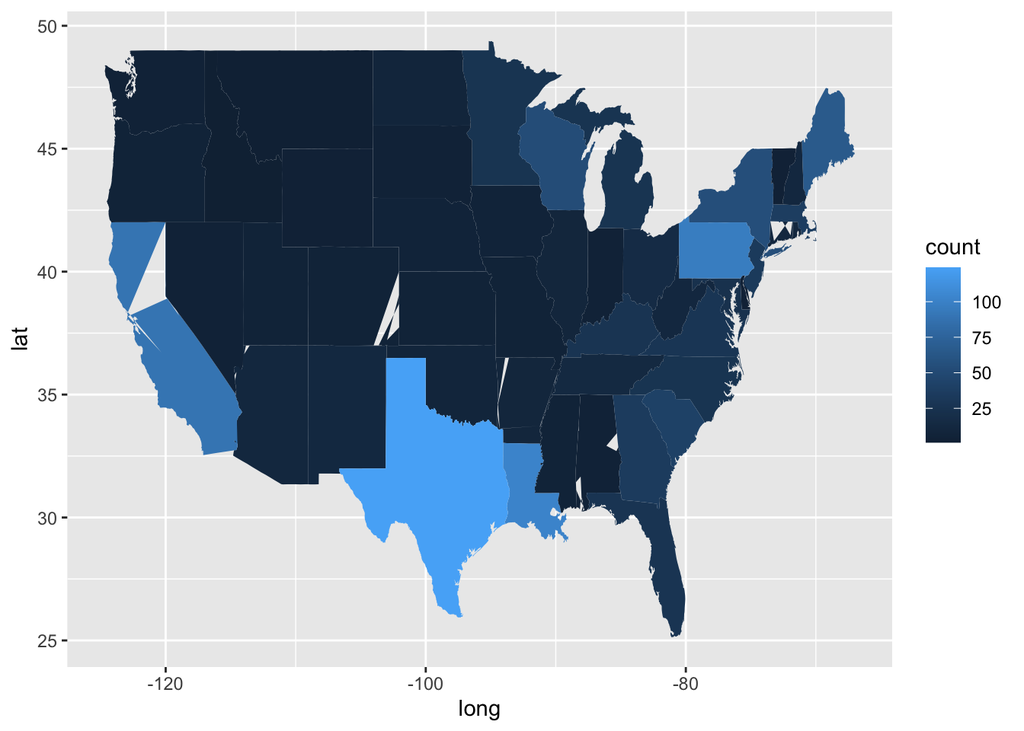

```r
ggplot(dialects.geo, aes(long, lat)) +
  geom_polygon(aes(group = group, fill = count))
```

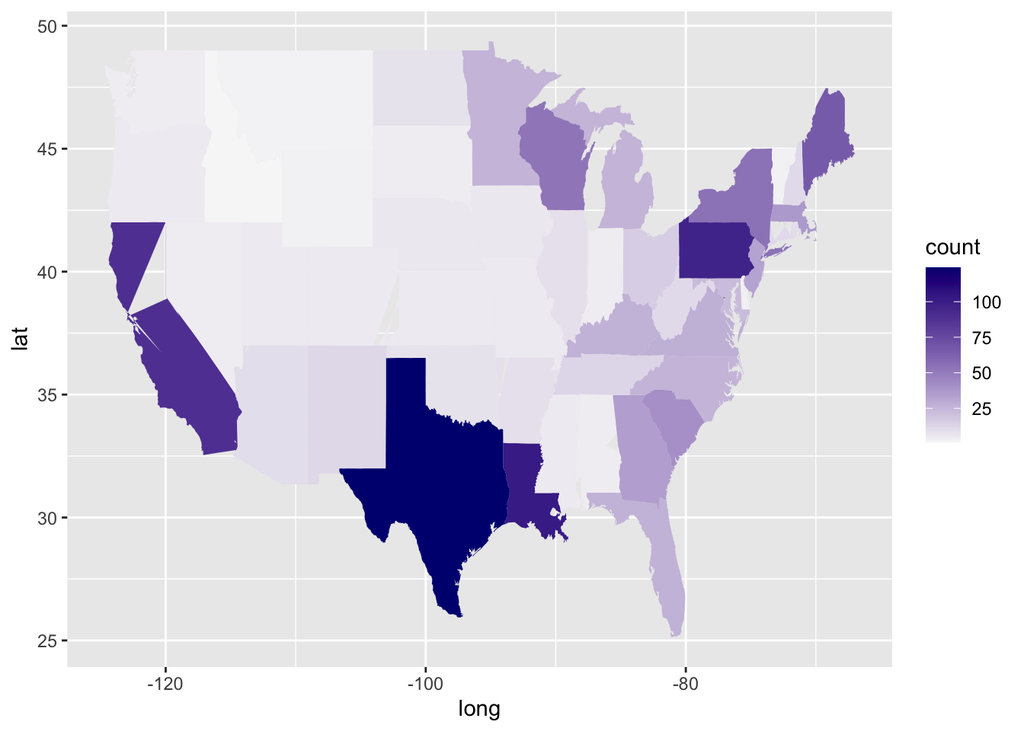

```r
ggplot(dialects.geo, aes(long, lat)) +
  geom_polygon(aes(group = group, fill = count)) +
  scale_fill_continuous(high = "Navy", low = "#f7f7f7")
```

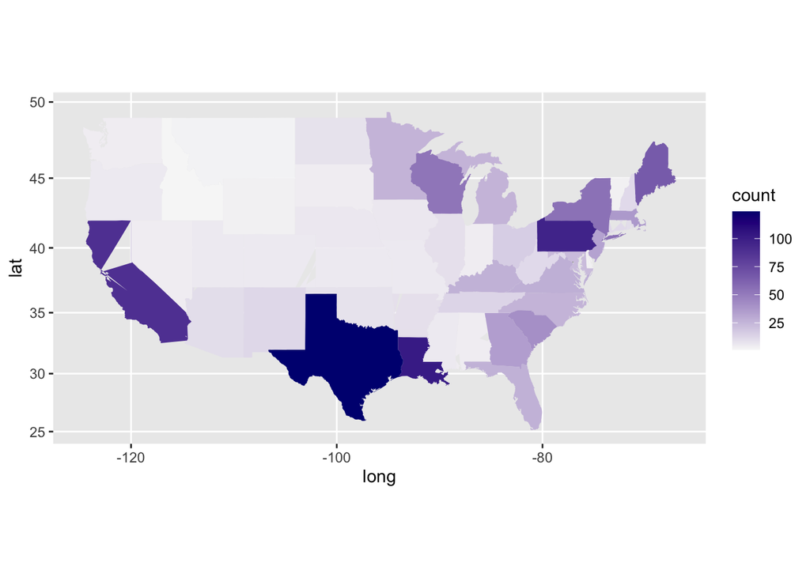

```r
ggplot(dialects.geo, aes(long, lat)) +
  geom_polygon(aes(group = group, fill = count)) +
  scale_fill_continuous(high = "Navy", low = "#f7f7f7")+
  coord_map()
```

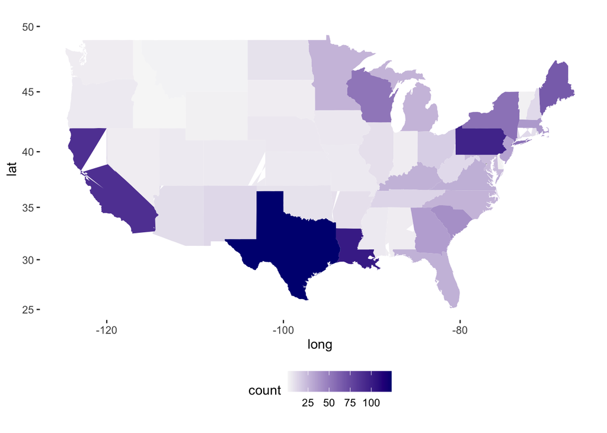

```r
ggplot(dialects.geo, aes(long, lat)) +
  geom_polygon(aes(group = group, fill = count)) +
  scale_fill_continuous(high = "Navy", low = "#f7f7f7")+
  coord_map()+
  theme(legend.position = "bottom",
        panel.background = element_blank())
```

#### 🤔 The `maps` package only shows the 48 contiguous states.

### Plot all 50 states using the `fiftystater` package by Will Murphy: https://github.com/wmurphyrd

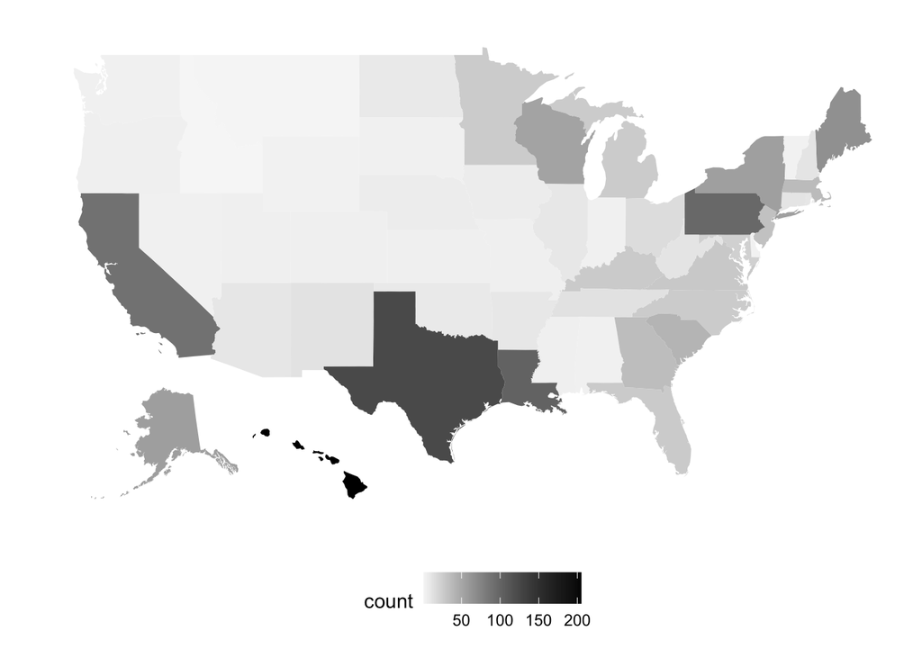

```r
ggplot(daredes.count, aes(map_id = dialect)) + # map_id creates the aesthetic mapping to the state name column
  geom_map(aes(fill = count), map = fifty_states) + # map points to the fifty_states shape data
  expand_limits(x = fifty_states$long, y = fifty_states$lat) +
  coord_map() +
  scale_fill_continuous(high = "black", low = "#f7f7f7")+
  scale_x_continuous(breaks = NULL) +
  scale_y_continuous(breaks = NULL) +
  labs(x = "", y = "") +
  theme(legend.position = "bottom",
        panel.background = element_blank())
```

#### * What are some hypotheses as to what drives the count of unique dialect across the USA?

#### * Is there information that this map may give that would not be as clear in a table or bar chart?